# Weight lifting classification

Oscar de León

### Overview

This report addresses my Practical Machine Learning ([predmachlearn-011](https://www.coursera.org/course/predmachlearn)) course project. It includes a description of the data processing steps, the rationale for model selection, the *model building process* the use of *cross-validation for estimation of the out of sample error*.

This compiled report contains code chunks to show the data analysis as it was performed. The lengthy code chunks are collapsed for readability (in [compatible browsers](http://www.w3schools.com/tags/tag_details.asp)) and can be expanded for revision by clicking on the sentences labeled as “section collapsed for readability”. For example:

**If the browser you are using does not support this feature… (section collapsed for readability)**

this text is shown upon page loading (as are the code chunks). Otherwise, it (and the code chunks) stay collapse until you open them.

The code is also available for review in the [repository](https://github.com/odeleongt/predmachlearn-011) containing this github page.

#### Getting and preparing data

```r
# Get data (downloads only if not available locally)
source(file = "./scripts/get_data.R")
```

**Read in data and clean up** (section collapsed for readability) I obtained the data as specified in the instructions, and loaded the training set in R. The dataset contained missing observations marked in a variety of ways (*i.e.* `NA`, `""`, `#DIV/0!`), all of which were explicitly marked as NA upon reading the data. I avoided the use of factors up to the model building, to prevent errors due to incompatible levels. I removed from the training data all the window summary rows (marked with `new_window == "yes"` in the training dataset) and all the summary columns (which contained mostly `NA`s, except for the summary rows).**

```r
source(file = "./scripts/prepare_data.R", echo = TRUE)
```

```
> training <- read.csv(file = "./data/pml-training.csv",
+     stringsAsFactors = FALSE, row.names = 1, na.strings = c("#DIV/0!",
+         "", "NA" .... [TRUNCATED]

> meta <- c("classe", "user_name", "raw_timestamp_part_1",
+     "raw_timestamp_part_2", "cvtd_timestamp", "new_window", "num_window")

> NAs <- sapply(X = training[!names(training) %in% meta],
+     FUN = function(col) mean(is.na(col)))

> mostly_NA <- names(NAs)[NAs > 0.95]

> training <- subset(x = training, subset = new_window ==
+     "no", select = names(training)[!names(training) %in% c(mostly_NA,
+     "new_window" .... [TRUNCATED]

> modes <- sapply(X = training, FUN = mode)

> vars <- sapply(X = training[, modes == "numeric"],
+     FUN = var, na.rm = TRUE)

> predictors <- names(training)[!names(training) %in%
+     meta]

> training_clean <- training[, c("classe", predictors)]
```

```r
# Set classe to factor, for use with randomForest
training_clean$classe <- factor(training_clean$classe)
```

**Using cross validation** (section collapsed for readability) I used single set cross validation to estimate the out of sample error of the model. For this I split the training dataset in training (60%) and validation (40%) datasets, and used the validation set to estimate the error as described in a section below.**

```r
set.seed(2015-02-22) # Set seed for reproducibility
rows_for_training <- sample(x = 1:nrow(training_clean),
                            size = ceiling(nrow(training_clean) * 0.6),
                            replace = FALSE)
training <- training_clean[rows_for_training, ]
validation <- training_clean[-rows_for_training, ]
```

### Building the model

In this section I describe the model building process. As exemplified in the figure below, there are non-linear relationships between the features contained in the dataset. Thus, I opted to build a randomForest model for its accuracy and to avoid using linear models.

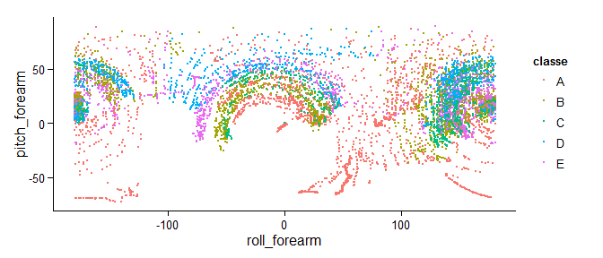

```r
qplot(data = training, x = roll_forearm, y = pitch_forearm,
      color = classe, size = I(0.5)) + theme_classic()
```

I trained the model with the `randomForest` package, using the default settings.

```r
set.seed(2015-02-22) # Set seed for reproducibility
trained <- randomForest(classe ~ ., data = training)
```

**Show model output (section collapsed for readability)**

```
Call:
 randomForest(formula = classe ~ ., data = training)
               Type of random forest: classification
                     Number of trees: 500
No. of variables tried at each split: 7

        OOB estimate of  error rate: 0.77%
Confusion matrix:
     A    B    C    D    E class.error
A 3271    4    0    0    2 0.001830943
B   17 2182    8    1    0 0.011775362
C    0   18 2021    4    0 0.010768478
D    0    0   26 1875    0 0.013677012
E    0    1    1    7 2092 0.004283674
```

### Out-of-sample error estimation

Although the model output shows an OOB estimate of error rate (0.77%), I used the generated model to predict the class for each observation in the validation set to estimate the out of sample error as required by the project instructions.

```r
validate_prediction <- predict(object = trained, newdata = validation)
(accuracy <- mean(validate_prediction == validation$classe))
```

```
## [1] 0.9942753
```

This results in an estimated 0.9942753 accuracy, or 0.6% out of sample error.

### The model in action

Using the developed model, I predicted the class for each observation in the test set and obtained all 20 results correctly.

```r
test <- read.csv(file = "./data/pml-testing.csv", stringsAsFactors = FALSE,
                     row.names = 1, na.strings = c("#DIV/0!", "", "NA"))
(test_prediction <- predict(object = trained, newdata = test))
```

```
##  1  2  3  4  5  6  7  8  9 10 11 12 13 14 15 16 17 18 19 20
##  B  A  B  A  A  E  D  B  A  A  B  C  B  A  E  E  A  B  B  B
## Levels: A B C D E
```

**Released under a [CC BY-SA](https://creativecommons.org/licenses/by-sa/4.0) license.**

This analysis uses data published under CC BY-SA, so it is considered a derivative use of the [Weight Lifting Exercises Dataset](http://groupware.les.inf.puc-rio.br/har#weight_lifting_exercises) by [Groupware@LES](http://groupware.les.inf.puc-rio.br/) and released under a compatible license as required (as declared in the repository README file).